# IntOMICS tutorial

Anna Pačínková

ana.pacinkova@gmail.com

26 listopadu 2022

#### Package

IntOMICS 0.99.5

# Contents

## 0.1 Summary

Multi-omics data from the same set of samples contain complementary information and may provide a more accurate and holistic view of the biological system consisting of different interconnected molecular components. Hence, a computational framework to infer regulatory relationships by integrating multiple modalities is one of the most relevant and challenging problems in systems biology.

IntOMICS is an efficient integrative framework based on Bayesian networks. IntOMICS systematically analyses gene expression (GE), DNA methylation (METH), copy number variation (CNV) and biological prior knowledge (B) to infer regulatory networks. IntOMICS complements the missing biological prior knowledge by so-called empirical biological knowledge (empB), estimated from the available  
experimental data.

An automatically tuned MCMC algorithm (Yang and Rosenthal, 2017) estimates model parameters and the empirical biological knowledge. Conventional MCMC algorithm with additional Markov blanket resampling (MBR) step (Su and Borsuk, 2016) infers resulting regulatory network structure consisting of three types of nodes: GE nodes refer to gene expression levels, CNV nodes refer to associated copy number variations, and METH nodes refer to associated DNA methylation probe(s). Regulatory networks derived from IntOMICS provide deeper insights into the complex flow of genetic information. IntOMICS is a powerful resource for exploratory systems biology and can provide valuable insights into the complex mechanisms of biological processes that has a vital role in personalised medicine.

IntOMICS takes as input `MatchedAssayExperiment` or named `list` with:

1. gene expression matrix,
2. associated copy number variation matrix sampled from the same individuals (optional),
3. associated DNA methylation matrix of beta-values sampled from the same individuals (optional), and
4. the biological prior knowledge with information on known interactions among molecular features (optional; highly recommended).

The resulting regulatory network structure contains the edge weights $w_i$ representing the empirical frequency of given edge over samples of network structures from two independent MCMC simulations.

For further details about the IntOMICS algorithm, its performance and benchmark analysis, see manuscript Pacinkova & Popovici, 2022.

Projects such as The Cancer Genome Atlas aim to catalogue multi-omics data from a large number of samples. IntOMICS framework is demonstrated using colon cancer data from the *curatedTCGA* package. However, it is not limited to any particular omics data or phenotype.

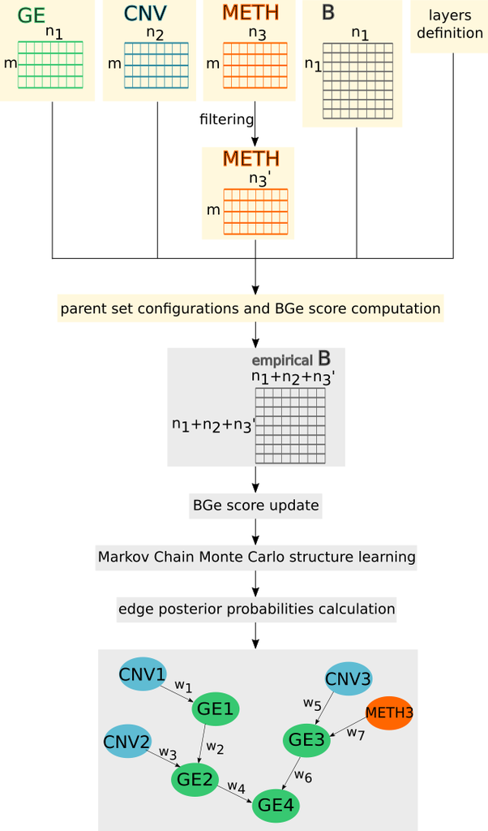

IntOMICS framework

## 0.2 Installation

```r
# bioconductor install
if (!requireNamespace("BiocManager", quietly = TRUE))
    install.packages("BiocManager")
BiocManager::install("IntOMICS")

# install the newest (development) version from GitHub
# install.packages("remotes")
remotes::install_github("anna-pacinkova/IntOMICS")
```

## 0.3 Usage

This tutorial will show you how to use the *IntOMICS* package  
with a toy example. The example dataset consisting of processed gene expression, DNA methylation (Illumina Infinium HumanMethylation450 BeadChip) and copy number variation is from the TCGA data portal (https://portal.gdc.cancer.gov/): primary colon cancer samples (COAD) with microsatellite instability (MSI). However,  
the approach is not limited to any phenotype. We choose the set of 8 genes from the KEGG Colorectal cancer pathway(https://www.genome.jp/pathway/hsa05210).

### 0.3.1 Part 1: Input data

```r
library(IntOMICS)

# load required libraries
suppressPackageStartupMessages({
library(curatedTCGAData)
library(TCGAutils)
library(bnlearn)
library(bnstruct)
library(matrixStats)
library(parallel)
library(RColorBrewer)
library(bestNormalize)
library(igraph)
library(gplots)})
```

IntOMICS framework takes as input:

1. gene expression matrix $GE$ ($m$ x $n_1$) with microarray intensities or RNA-seq count data transformed into a continuous domain ($m$ samples and $n_1$ features)
2. associated copy number variation matrix $CNV$ ($m$ x $n_2$) with continuous segment mean values derived for each gene ($n_2 \leq n_1$),
3. associated DNA methylation matrix of beta-values $METH$ ($m$ x $n_3$),
4. data.frame including all known interactions between molecular features (information from public available databases such as KEGG (Ogata et al., 1999) or REACTOME (Wu & Haw, 2017)). Any other source of prior knowledge can be used. (IntOMICS is designed to run even if prior knowledge is not available. However, we highly recommend to use it.)
5. logical matrix with known transcription factors (TFs) and its targets (information from public available databases such as ENCODE (ENCODE Project Consortium, 2004). Any other source can be used. (IntOMICS is designed to run even if any TF-target interaction is not available.)

All data matrices are sampled from the same individuals.

We use *curatedTCGA* package to obtain publicly available toy dataset from The Cancer Genome Atlas (TCGA):

Available omics data are saved in a MatchedAssayExperiment object including gene expression (GE) of 8 genes + copy number variation (CNV) of 8 genes + beta value of 9 DNA methylation (METH) probes:

```r
t(assay(omics[["ge"]]))[1:5,1:5]
```

```
##                                WNT2B     FZD2     DVL3     GSK3B     AXIN1
## TCGA-A6-2686-01A-01R-A32Z-07 98.0010 170.1609 2101.414 1301.3164  781.0824
## TCGA-AA-3492-01A-01R-1410-07 28.3415  60.5921 1354.526 1031.0424  957.7456
## TCGA-AZ-4313-01A-01R-1410-07  6.6194  35.4610 1324.350  671.3948 1150.3546
## TCGA-AZ-4615-01A-01R-1410-07 23.5544  88.5644 1895.183 1139.5595  986.9273
## TCGA-CK-4951-01A-01R-1410-07 66.1451 111.6643 1830.014 1331.7923  943.1010
```

These values correspond to normalised RNA-seq data (in this case transcripts per million (TPM)). However, the user is not limited to this platform. Another assay, such as microarray data, can be used.

```r
t(assay(omics[["cnv"]]))[1:5,1:5]
```

```
##                              WNT2B    FZD2     DVL3    GSK3B    AXIN1
## TCGA-A6-2686-01A-01D-1549-01 "-0.004" "0.360"  "0.322" "0.322"  "-0.054"
## TCGA-AA-3492-01A-01D-1406-01 "0.001"  "-0.026" "0.010" "0.010"  "-0.028"
## TCGA-AZ-4313-01A-01D-1406-01 "0.000"  "-0.015" "0.014" "0.014"  "-0.017"
## TCGA-AZ-4615-01A-01D-1406-01 "-0.676" "-0.001" "0.009" "-0.002" "-0.001"
## TCGA-CK-4951-01A-01D-1406-01 "0.005"  "0.001"  "0.005" "0.012"  "-0.009"
```

These copy number values represent segment mean values equal to $log_2(\frac{copy-number}{2})$. In the `omics$cnv` matrix, define only columns with available CNV data.

```r
t(assay(omics[["meth"]]))[1:5,1:5]
```

```
## <5 x 5> matrix of class DelayedMatrix and type "double":
##                              cg14479617 cg12588208 cg27308245 cg26525629
## TCGA-A6-2686-01A-01D-1407-05  0.9084623  0.9215509  0.8980271  0.9290444
## TCGA-AA-3492-01A-01D-1407-05  0.9149863  0.9533260  0.7354531  0.9134177
## TCGA-AZ-4313-01A-01D-1407-05  0.8303245  0.7100104  0.8236161  0.8826254
## TCGA-AZ-4615-01A-01D-1407-05  0.8120547  0.9296065  0.9111442  0.9245422
## TCGA-CK-4951-01A-01D-1407-05  0.8916593  0.9104083  0.9168872  0.9046989
##                              cg04571584
## TCGA-A6-2686-01A-01D-1407-05  0.4727044
## TCGA-AA-3492-01A-01D-1407-05  0.3585817
## TCGA-AZ-4313-01A-01D-1407-05  0.4161686
## TCGA-AZ-4615-01A-01D-1407-05  0.5829655
## TCGA-CK-4951-01A-01D-1407-05  0.5282824
```

These values represent DNA methylation beta values of given probes (defined by IDs).

IntOMICS is designed to infer regulatory networks even if the copy number variation or DNA methylation data (or both) are not available. In such a case, omics must be a MatchedAssayExperiment with gene expression.

If methylation data are available, we have to provide an annotation:

```r
str(annot)
```

```
## List of 5
##  $ GSK3B : chr [1:2] "cg14479617" "cg12588208"
##  $ AXIN1 : chr [1:2] "cg27308245" "cg26525629"
##  $ WNT2B : chr "cg04571584"
##  $ CTNNB1: chr [1:3] "cg04180460" "cg06626556" "cg02247160"
##  $ FZD2  : chr "cg09339219"
```

`annot` is a named list. Each component of the list is a character vector and corresponds to probe IDs associated with a given gene.

We also have to provide a gene annotation table:

```r
gene_annot
```

```
##    entrezID gene_symbol
## 14 EID:7482       WNT2B
## 21 EID:2535        FZD2
## 34 EID:1857        DVL3
## 35 EID:2932       GSK3B
## 38 EID:8312       AXIN1
## 40 EID:1499      CTNNB1
## 36  EID:324         APC
## 43 EID:6934      TCF7L2
```

`gene_annot` is Gene ID conversion table with “entrezID” and “gene_symbol” column names. Entrez IDs are used in for regulatory network inference, gene symbols are used for the final regulatory network visualisation.

And finally, the prior knowledge from any source chosen by the user:

```r
data("PK")
PK
```

```
##   src_entrez dest_entrez edge_type
## 1   EID:7482    EID:2535   present
## 2   EID:2535    EID:1857   present
## 3   EID:1857    EID:2932   present
## 4    EID:324    EID:1499   present
## 5    EID:324    EID:1857   present
## 6   EID:8312     EID:324   present
```

`PK` is the data.frame with biological prior knowledge about known interactions between features. Column names are “src_entrez” (the parent node), “dest_entrez” (the child node) and “edge_type” (the prior knowledge about the direct interaction between parent and child node; the allowed values are “present” or “missing”).

```r
data("TFtarg_mat")
TFtarg_mat[1:5,1:5]
```

```
##            EID:1820 EID:466 EID:1386 EID:467 EID:571
## EID:1             1       0        0       0       0
## EID:503538        1       0        0       0       0
## EID:29974         1       0        0       0       0
## EID:2             1       0        0       0       0
## EID:144568        0       0        1       0       0
```

`TFtarg_mat` is a logical matrix with known transcription factors (TFs) and its targets. TFs are listed in columns, corresponding targets are listed in rows.

```r
data("layers_def")
layers_def
```

```
##   omics layer fan_in_ge
## 1    ge     2         3
## 2   cnv     1         1
## 3  meth     1        NA
```

`layers_def` is a data.frame containing:

1. the modality ID (character vector); must be same as names of `omics` MatchedAssayExperiment object,
2. corresponding layer in IntOMICS MCMC scheme (numeric vector); edges from the lowest layer (must be always GE) to the CNV/METH layers are excluded from the set of candidate edges), and
3. maximal number of parents from given layer to GE nodes (numeric vector).

### 0.3.2 Part 2: Data preprocessing

The first step is to define the biological prior matrix and estimate the upper bound of the partition function needed to define the prior distribution of network structures. We also need to define all possible parent set configurations for each node. For each parent set configuration, we compute the energy (needed to define the prior distribution of network structures) and the BGe score (needed to determine the posterior probability of network structures). These functionalities are available through the `OMICS_module` function. We can use linear regression to filter irrelevant DNA methylation probes. In such a case, we set the parameter “lm_METH = TRUE”. We can also specify the threshold for the R^2 to choose DNA methylation probes with significant coefficient using argument “r_squared_thres” (default = 0.3), or p-value using “p_val_thres” (default = 0.05). There are several other arguments: “woPKGE_belief” (default = 0.5) refers to the belief concerning GE-GE interactions without prior knowledge, “nonGE_belief” (default = 0.5) refers to the belief concerning the belief concerning interactions of features except GE (e.g. CNV-GE, METH-GE), “TFBS_belief” refers to the belief concerning the TF and its target interaction (default = 0.75). Note that all interactions with belief equal to “woPKGE_belief” in biological prior knowledge will be updated in empirical biological knowledge.

```r
OMICS_mod_res <- omics_module(omics = omics,
                              PK = PK,
                              layers_def = layers_def,
                              TFtargs = TFtarg_mat,
                              annot = annot,
                              gene_annot = gene_annot,
                              lm_METH = TRUE,
                              r_squared_thres = 0.3,
                              p_val_thres = 0.1)
```

This function returns several outputs:

```r
names(OMICS_mod_res)
```

```
## [1] "pf_UB_BGe_pre"       "B_prior_mat"         "annot"
## [4] "omics"               "layers_def"          "omics_meth_original"
```

1. `OMICS_mod_res$pf_UB_BGe_pre` is a list that contains:
- `OMICS_mod_res$pf_UB_BGe_pre$partition_func_UB` the upper bound of the partition function for hyperparameter $\beta = 0$,
- `OMICS_mod_res$pf_UB_BGe_pre$parents_set_combinations` all possible parent set configuration for given node,
- `OMICS_mod_res$pf_UB_BGe_pre$energy_all_configs_node` energy for given parent set configurations,
- `OMICS_mod_res$pf_UB_BGe_pre$BGe_score_all_configs_node` BGe score for given parent set configurations.
2. `OMICS_mod_res$B_prior_mat` is a biological prior matrix.
3. `OMICS_mod_res$annot` contains DNA methylation probes that passed the filter.
4. `OMICS_mod_res$omics` is a list with gene expression, copy number variation and normalised methylation data (possibly filtered if we use “lm_METH = TRUE”).
5. `OMICS_mod_res$omics_meth_original` the original methylation data.

### 0.3.3 Part 3: MCMC simulation

We use the automatically tuned MCMC algorithm (Yang and Rosenthal, 2017) with default setting to estimate model hyperparameter $\beta$ and empirical biological knowledge matrix through multiple phases.

1. The first adaptive phase is used to roughly tune the hyperparameter $\beta$, more precisely the variance of its proposal distribution.
2. The transient phase is applied to diagnose whether the chain has reached the mode of the target distribution.
3. The second adaptive phase is used to fine-tune the hyperparameter $\beta$, the variance of its proposal distribution and to compute the empirical biological prior matrix. Assuming there is no prior knowledge aboit interaction from node *i* to node *j*, the prior knowledge about interaction from node *i* to node *j* is updated during the second adaptive phase after every conventional edge proposal move (addition, deletion, reversal).  
   The empirical biological knowledge corresponds to the ratio of acceptance (number of iterations with accepted candidate edge from~node *i* to~node *j*) and frequency (number of iterations with proposed candidate edge from~node *i* to~node *j*). Reversing an edge is equivalent to deleting the edge and adding the edge in the opposite direction.
4. The empirical biological matrix and the hyperparameter $\beta$ determined by<sub>the</sub>second adaptive phase are used in the last sampling phase. In this phase, IntOMICS applies a *greedy horizon* approach. Three independent paths are executed with a fixed BGe score (except the MBR step). The most probable path is chosen after every 500 iterations.  
   The conventional MCMC algorithm with additional Markov blanket resampling step (Su and Borsuk, 2016) to infer regulatory network structure consisting of three types of nodes: GE, CNV and METH nodes. Two independent samples of network structures are produced to evaluate the convergence of the Markov chain. Each sample consists of 2*`burn_in` DAGs. The~resulting samples of DAGs are thinned - discarded all but every `thin` DAG. The burn-in period and thinning frequency are arbitrary choices.

```r
BN_mod_res_sparse <- bn_module(burn_in = 500,
                               thin = 20,
                               OMICS_mod_res = OMICS_mod_res,
                               minseglen = 5)
```

**Because of the MCMC simulation, `bn_module` function is time-consuming. For the illustration, we have used only short burn-in period of the resulting Markov chain. We recommend to use much longer burn-in period and check trace plots of the MCMC simulation. We recommend to use burn_in = 100.000, thin = 500, and minseglen = 50.000 (for further details see (Pacinkova & Popovici, 2022)).** To investigate relevant IntOMICS outputs, use the pre-computed result saved in `BN_mod_res` R object).  
There are two optional arguments: “len” specifies the initial width of the sampling interval for hyperparameter $\beta$. However, this parameter will be tuned during the adaptive phases of the MCMC algorithm. “prob_mbr” specifies the probability of the MBR step (default = TRUE). We strongly recommend to use the default setting (for further details on how this argument affects MCMC scheme results, see (Su and Borsuk, 2016)).

Let’s check the outputs of `BN_module` function:

```r
data("BN_mod_res")
names(BN_mod_res)
```

```
## [1] "sampling.phase_res"   "B_prior_mat_weighted" "beta_tuning"
```

1. `BN_mod_res$B_prior_mat_weighted` is empirical biological knowledge matrix. Interactions from the biological prior knowledge and TFs-target interactions are constant (if “TFBS_belief” is not equal to “woPKGE_belief”).
2. `BN_mod_res$sampling.phase_res` is a named list with results from the last sampling phase of the algorithm:
- `BN_mod_res$sampling.phase_res$rms` trace of root mean square used for c_rms measure to evaluate the convergence of MCMC simulation,
- `BN_mod_res$sampling.phase_res$mcmc_sim_part_res` contains CPDAGs of two independent MCMC simulations (for details see (Pacinkova & Popovici, 2022)).
4. `BN_mod_res$beta_tuning` is a named list for each iteration of adaptive phases that contains:
- `BN_mod_res$beta_tuning$value` trace of hyperparameter beta tuning,
- `BN_mod_res$beta_tuning$len` trace of width of the sampling interval for hyperparameter $\beta$.

### 0.3.4 Part 4: MCMC diagnostics

Trace plots provide an important tool for assessing mixing of a Markov chain and  
should be inspected carefully. We can generate them using the `trace_plots` functions:

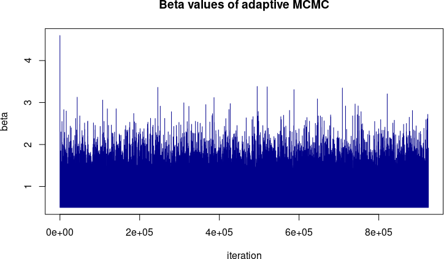

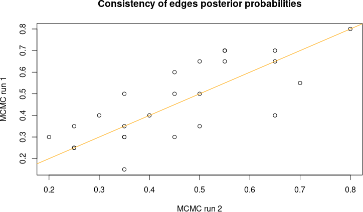

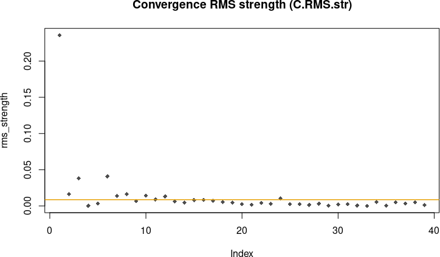

```r
trace_plots(mcmc_res = BN_mod_res,
            burn_in = 10000,
            thin = 500,
            edge_freq_thres = 0.5)
```

The `trace_plots` function generates:

1. trace plot of beta values (we want to explore the sample space many times and avoid flat bits - the chain stays in the same state for too long; in this case, beta value fluctuates around single value, so the Markov chain is mixing well).
2. consistency of edges posterior probabilities in two independent MCMC simulations (scatter plot of the edge weights confidence using two independent MCMC runs; the convergence is determined by the spread of the points around the y=x line; in this case, the edge weights seems to be consistent in two independent simulations).
3. the c<sub>rms</sub> strength for the convergence evaluation (summarizes the spread of the points around the line y=x, for details see (Agostinho et al., 2015) and (Pacinkova & Popovici, 2022)).

The parameter “edge_freq_thres” determines the quantile of all edge weights used to filter only reliable edges (default = NULL, all edges will be considered as present). For illustration, we use quite low edge weights filter to capture interactions between features from different layers. We recommend to use some edge weights filtering, such as 0.75 quantile of all edge weights in the resulting networks using “edge_freq_thres = 0.75”.

Now we use `edge_weights` and `weighted_net` functions to define the resulting regulatory network inferred by *IntOMICS* with specific thresholds:

```r
res_weighted <- edge_weights(mcmc_res = BN_mod_res,
                            burn_in = 10000,
                            thin = 500,
                            edge_freq_thres = 0.5)

weighted_net_res <- weighted_net(cpdag_weights = res_weighted,
                                 gene_annot = gene_annot,
                                 PK = PK,
                                 OMICS_mod_res = OMICS_mod_res,
                                 gene_ID = "gene_symbol",
                                 TFtargs = TFtarg_mat,
                                 B_prior_mat_weighted = BN_mod_res$B_prior_mat_weighted)
```

The parameter “gene_ID” determines the IDs used in the final network. There are two options: “gene_symbol” (default) or “entrezID”.

### 0.3.5 Part 5: IntOMICS resulting network structure

We can plot the resulting regulatory network inferred by *IntOMICS* using `ggraph_weighted_net` (node size and label size can be modified) and `legend_custom_ggplot` functions and arrange them into one figure:

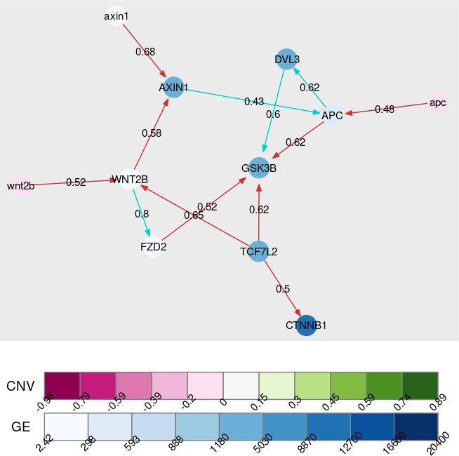

```r
library(cowplot)
# weighted_net_legend(net = weighted_net_res)
plot_grid(rn, leg, ncol = 1, rel_heights = c(3, 1))
```

Edges highlighted in blue are known from the biological prior knowledge. The edge labels reflects its empirical frequency over the final set of CPDAGs. GE node names are in upper case, CNV node names are in lower case, METH node names are the same as DNA methylation probe names in `omics$meth` matrix. Node colour scales are given by GE/CNV/METH values of all features from the corresponding input data matrix.

We can also change the edge labels to inspect the empirical prior knowledge inferred by *IntOMICS* using the argument “edge_weights = empB” (default = “MCMC_freq”):

```r
res_weighted <- edge_weights(mcmc_res = BN_mod_res,
                            burn_in = 10000,
                            thin = 500,
                            edge_freq_thres = 0.5)

weighted_net_res <- weighted_net(cpdag_weights = res_weighted,
                                 gene_annot = gene_annot,
                                 PK = PK,
                                 OMICS_mod_res = OMICS_mod_res,
                                 gene_ID = "gene_symbol",
                                 edge_weights = "empB",
                                 TFtargs = TFtarg_mat,
                                 B_prior_mat_weighted = BN_mod_res$B_prior_mat_weighted)
```

```r
# plot_grid(rn, leg, ncol = 1, rel_heights = c(3, 1))
```

Function `empB_heatmap` can be used to check the difference between empirical biological knowledge and biological prior knowledge in GE-GE interactions:

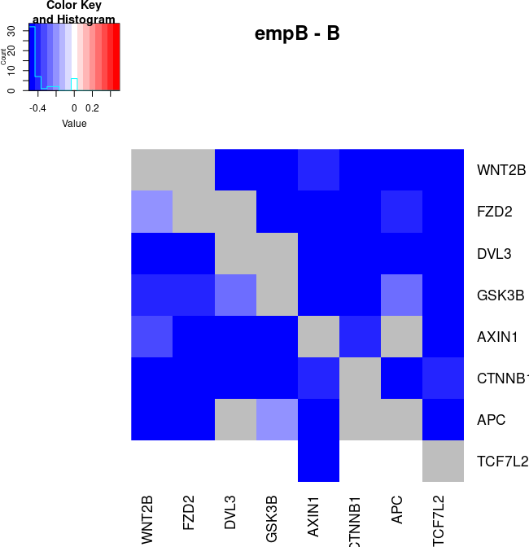

```r
emp_b_heatmap(mcmc_res = BN_mod_res,
             OMICS_mod_res = OMICS_mod_res,
             gene_annot = gene_annot,
             TFtargs = TFtarg_mat)
```

Interactions with constant biological knowledge are highlighted in gray.

Interesting could be also density of the edge weights inferred by *IntOMICS*. First of all, we have to use the `edge_weights` function without the edge weights filtering:

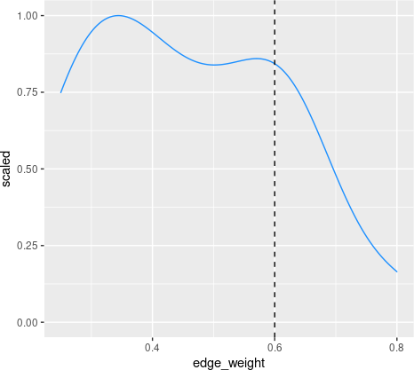

```r
res_weighted <- edge_weights(mcmc_res = BN_mod_res,
                            burn_in = 10000,
                            thin = 500,
                            edge_freq_thres = NULL)

weighted_net_res <- weighted_net(cpdag_weights = res_weighted,
                                 gene_annot = gene_annot,
                                 PK = PK,
                                 OMICS_mod_res = OMICS_mod_res,
                                 gene_ID = "gene_symbol",
                                 TFtargs = TFtarg_mat,
                                 B_prior_mat_weighted = BN_mod_res$B_prior_mat_weighted)

dens_edge_weights(weighted_net_res)
```

## 0.4 References

1. Yang, J. & Rosenthal, J. S. (2017). Automatically tuned general-purpose MCMC via new adaptive diagnostics. Computational Statistics, 32, 315 – 348.
2. Su, C. & Borsuk, M. E. (2016). Improving Structure MCMC for Bayesian Networks through Markov Blanket Resampling. Journal of Machine Learning Research, 17, 1 – 20.
3. Pacinkova, A. & Popovici, V. (2022). Using Empirical Biological Knowledge to Infer Regulatory Networks From Multi-omics Data. BMC Bioinformatics, 23. Ogata, H., et al. (1999). KEGG: Kyoto Encyclopedia of Genes and Genomes. Nucleic Acids Res 27, 29–34.
4. Wu, G. & Haw, R. (2017). Functional Interaction Network Construction and Analysis for Disease Discovery. Methods Mol Biol. 1558, 235–253. ENCODE Project Consortium (2004). The ENCODE (ENCyclopedia Of DNA Elements) Project. Science 22, 636-40.
5. Agostinho, N. B. et al. (2015). Inference of regulatory networks with a convergence improved MCMC sampler. BMC Bioinformatics, 16.